# Predicting reproductive toxicity: a model for PFAS-like chemical structures

### Significant androgen receptor chemotypes

Smarts.plus is a web based tool that can read SMARTS strings and convert them to visual representations. Since the chemotypes in the MACCS fingerprint are in SMARTS, this tool was used to visualize the results. Note that the ring structures (MACCS Fingerprint 96 and MACCS Fingerprint 145) were unable to be visualized, so the simplest carbon ring system was used to represent those chemotypes.

C..C..A..A (MACCS Fingerprint 26)

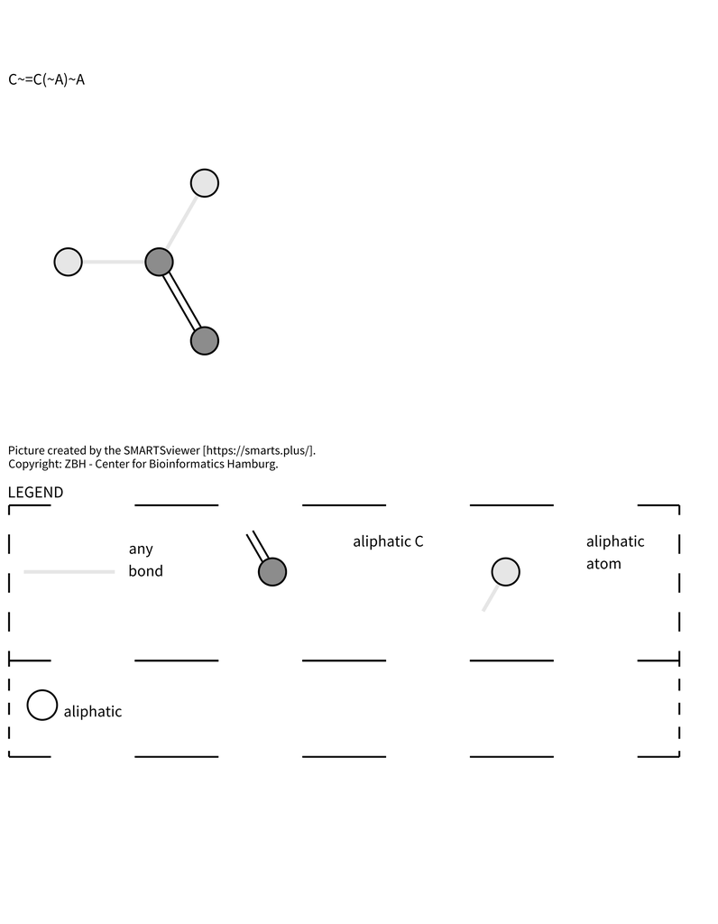

CC.C..C.A : (MACCS Fingerprint 66)

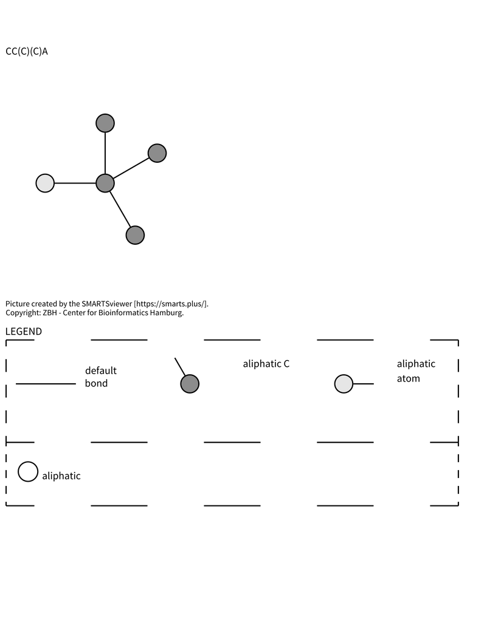

A.A..A..A : (MACCS Fingerprint 105)

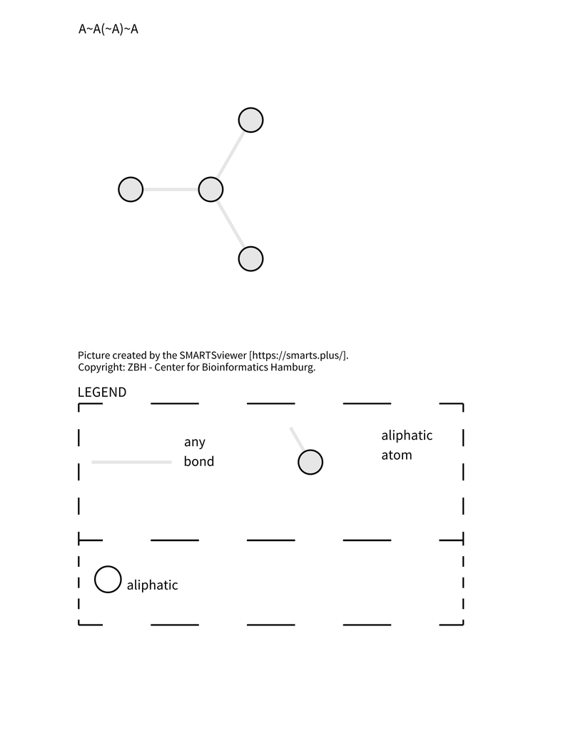

X5.M.ring : (MACCS Fingerprint 96)

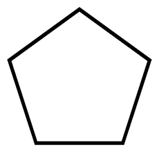

C.C.C.C : (MACCS Fingerprint 50)

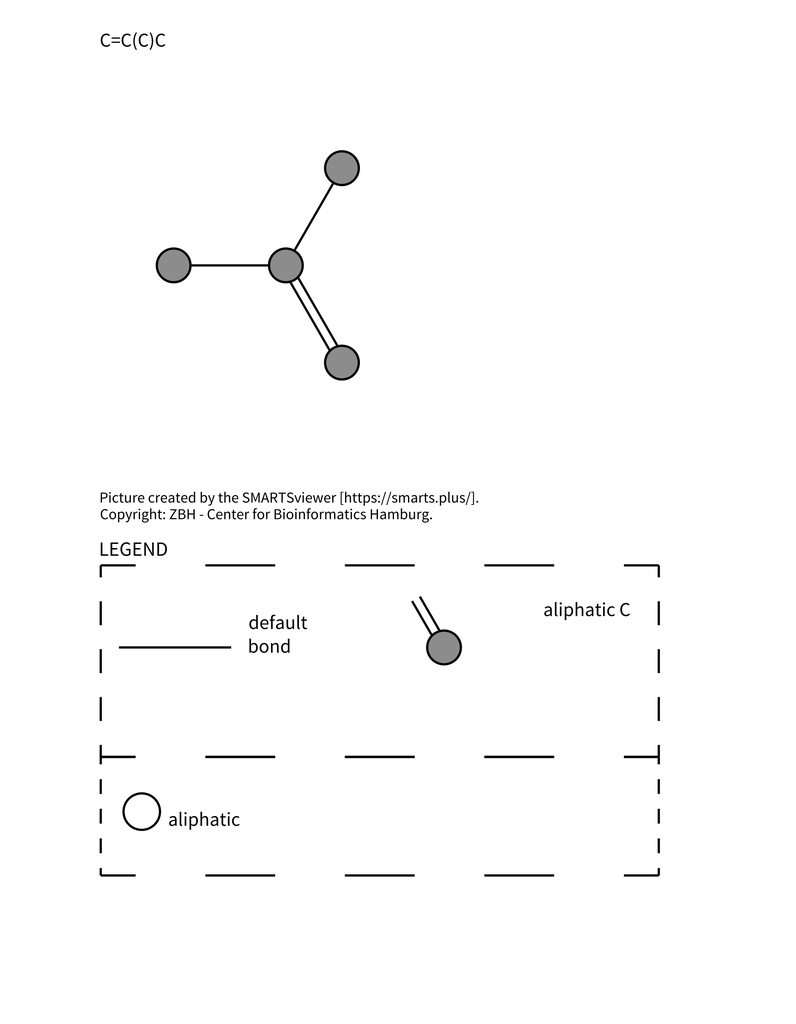

C.C : (MACCS Fingerprint 99)

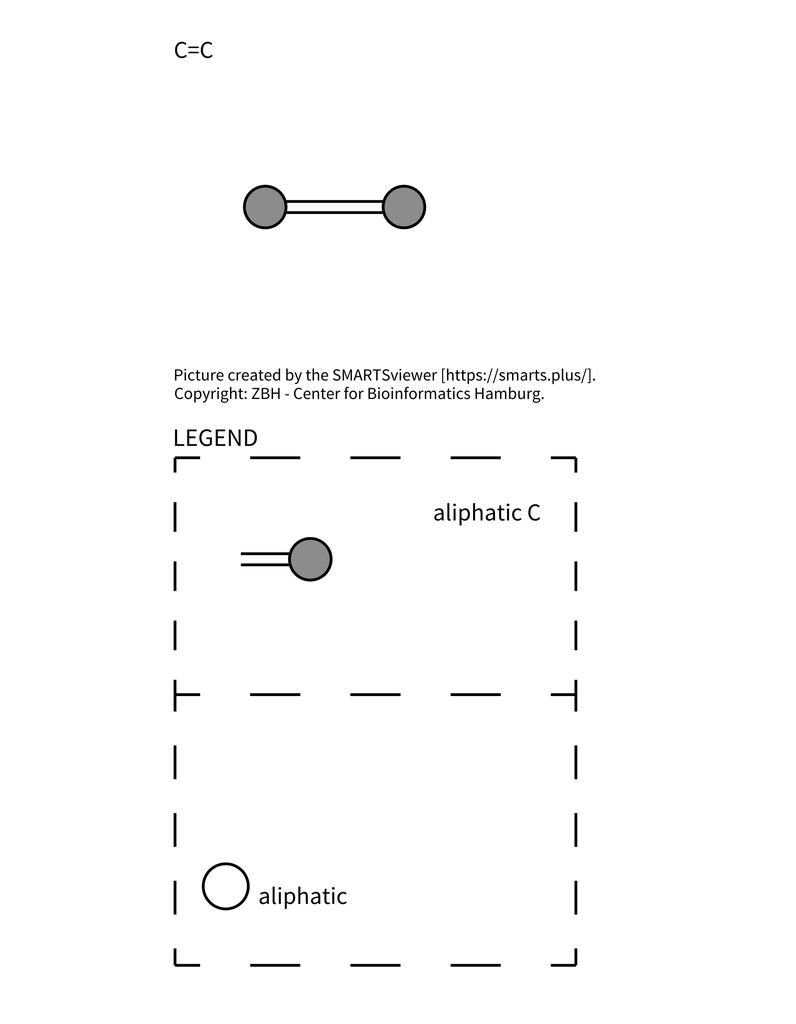

C.C.A.A : (MACCS Fingerprint 76)

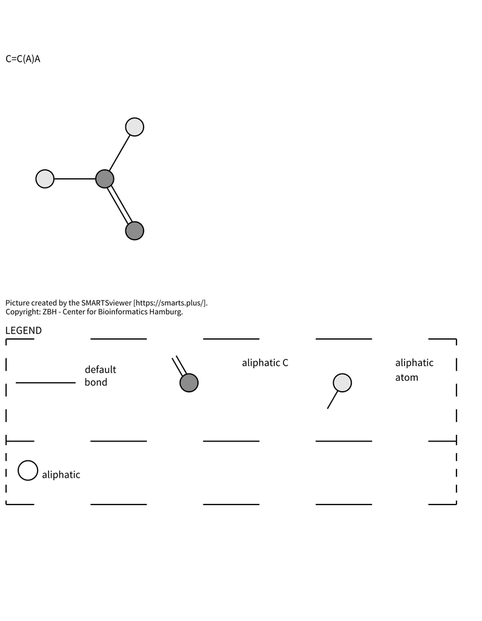

X6M.ring…1 : (MACCS Fingerprint 145)

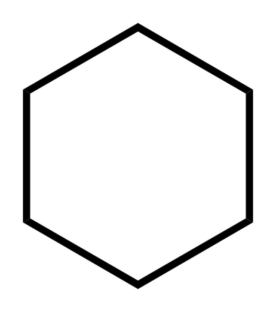

### Limitations

The first potential limitation of the study was due to computational power. The models were created using 100 trees, and validated 5 cross fold.

A potential limitation of the study might be the validation of the top chemotypes through making models only with the top chemotypes. Estrogen receptor agonist and antagonist only had 2 chemotypes that were significant and in common. This great reduction of features must have greatly impacted the predictive abilities of the model.

Another limitation involves the final visualization of the chemotypes. The SMARTS system has dedicated programs to deciphering the chemical structure and properties that were not used in this project.

### Future Directions

These results are interesting and should be followed up on. A clear next step is to test the androgran receptor agonist models on unseen data, perhaps on all 15,000 known PFAS congers. The predictions from the model should also be validated experimentally, which is possible given the TOX21 public assay protocols. The interactions between the chemotypes and the androgen receptor should also be explored and visualized through molecular docking simulations.

## Acknowledgments

I would like to acknowledge both my mentors for their guidance setting up the project. I would like to particularly thank Dr. Joe Romano for his help with retrieving the datasets. I would also like to acknowledge graduate student Alan Boka (Ostap lab, Department of Physiology) for his help with code assistance regarding the css chunk as well as his encouragement throughout. Talking through my project and logic with Alan was advantageous to my development with computational analysis.

## References

1. Romano JD, Hao Y, & Moore JH. (2022) Improving QSAR Modeling for Predictive Toxicology using Publicly Aggregated Semantic Graph Data and Graph Neural Networks. Pacific Symposium on Biocomputing 27: 187-198.
2. Vagi, S.J., Azziz-Baumgartner, E., Sjödin, A. *et al.* Exploring the potential association between brominated diphenyl ethers, polychlorinated biphenyls, organochlorine pesticides, perfluorinated compounds, phthalates, and bisphenol a in polycystic ovary syndrome: a case–control study. *BMC Endocr Disord* **14**, 86 (2014). https://doi.org/10.1186/1472-6823-14-86
3. J. Lyngsø, C.H. Ramlau-Hansen, B.B. Høyer, H. Støvring, J.P. Bonde, B.A.G. Jönsson, C.H. Lindh, H.S. Pedersen, J.K. Ludwicki, V. Zviezdai, G. Toft, Menstrual cycle characteristics in fertile women from Greenland, Poland and Ukraine exposed to perfluorinated chemicals: a cross-sectional study, *Human Reproduction*, Volume 29, Issue 2, February 2014, Pages 359–367, https://doi.org/10.1093/humrep/det390
4. Sakr CJ, Leonard RC, Kreckmann KH, Slade MD, Cullen MR. Longitudinal study of serum lipids and liver enzymes in workers with occupational exposure to ammonium perfluorooctanoate. J Occup Environ Med. 2007 Aug;49(8):872-9. doi: 10.1097/JOM.0b013e318124a93f. Erratum in: J Occup Environ Med. 2007 Nov;49(11):1294. PMID: 17693785.
5. Fei C, McLaughlin JK, Lipworth L, Olsen J. Maternal levels of perfluorinated chemicals and subfecundity. Hum Reprod. 2009 May;24(5):1200-5. doi: 10.1093/humrep/den490. Epub 2009 Jan 28. PMID: 19176540.
6. https://www.niehs.nih.gov/health/topics/agents/pfc/index.cfm, last updated October 05, 2023.
7. https://www.ewg.org/interactive-maps/pfas_contamination, last updated August 18, 2023
8. Vladimir Svetnik, Andy Liaw, Christopher Tong, J. Christopher Culberson, Robert P. Sheridan, and Bradley P. Feuston, Journal of Chemical Information and Computer Sciences **2003** *43* (6), 1947-1958, DOI: 10.1021/ci034160g
9. Huang R. A Quantitative High-Throughput Screening Data Analysis Pipeline for Activity Profiling. In: Zhu H, Xia M, editors. High-Throughput Screening Assays in Toxicology. Methods in Molecular Biology. 1473. 1 ed: Humana Press; 2016
10. Huang R, Xia M, Sakamuru S, Zhao J, Shahane SA, Attene-Ramos M, Zhao T, Austin CP, Simeonov A. (2016) Modelling the Tox21 10 K chemical profiles for in vivo toxicity prediction and mechanism characterization. Nat Commun. 7:10425
11. Huang R, Xia M, Sakamuru S, Zhao J, Lynch C, Zhao T, Zhu H, Austin CP, Simeonov A. (2018) Expanding biological space coverage enhances the prediction of drug adverse effects in human using in vitro activity profiles. Sci Rep. 8(1):3783
12. Berg KA, Clarke WP. Making Sense of Pharmacology: Inverse Agonism and Functional Selectivity. Int J Neuropsychopharmacol. 2018 Oct 1;21(10):962-977. doi: 10.1093/ijnp/pyy071. PMID: 30085126; PMCID: PMC6165953.
13. https://list.indiana.edu/sympa/arc/chminf-l/2007-11/msg00058.html
14. https://www.daylight.com/dayhtml/doc/theory/theory.smarts.html
15. https://smarts.plus